```python
from IPython.display import Image
```

# Unsupervised Clustering - Theory

## Unsupervised Learning

In supervised learning, we use a set of dependent variables $X$ to predict an independent variable $y$.

In unsupervised learning, there are no dependent variables. Rather than thinking about prediction, we are looking to discover patterns and subgroups from the data.

- The data has $n$ observations and $p$ features $X_1, X_2,...,X_p$

## Unsupervised Clustering - Introduction

In unsupervised clustering, we aim to aggregate data points into meaningful subgroups. We will be looking at two methods for this:

- K-mean clustering
- Hierarchical clustering

In K-mean clustering, we partition data into a pre-specified number of clusters. Each cluster is formed based off of distance between points.

In hierarchical clustering, we do not specify the number of clusters and the outcome is a tree-like visual representation of the data.

## K-Mean Clustering

### Overview

1. Define number of clusters (this is our $K$)
2. Assign each data point to exactly one of the $K$ clusters based off of a distance metric between observations

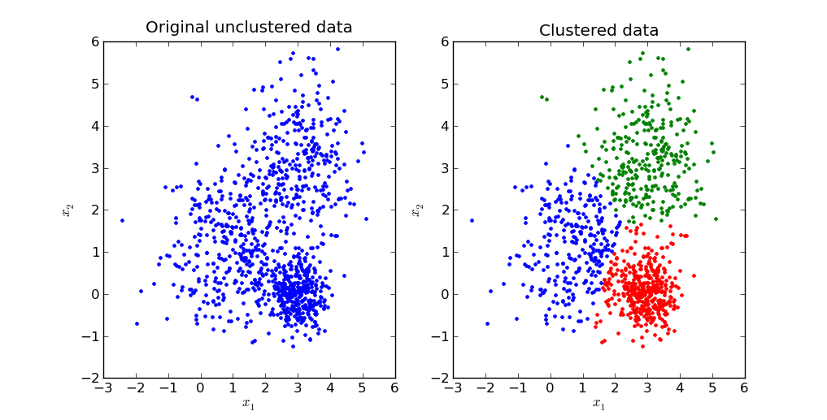

```python
Image('img/kmeans_2d.png')
```

Source: PyPR Documentation

In this example, $K=3$.

### Within-Cluster Variation

We aim to minimize the variation within each cluster $C_k$, denoted by $W(C_k)$.

- This can be seen as the extent to which data points in a cluster differ from one another
- Minimizing the within-cluster variation provides an argument that the data points in a cluster are similar to one another and should be grouped together

$W(C_k)$ is defined through squared Euclidean distance as:

- $W(C_k)=\frac{1}{|C_k|}\sum_{i,i'\in{C_k}}\sum_{j=1}^{p}(x_{ij}-x_{i'j})^2$
- Here, $|C_k|$ indicates the # of observations in the $k$-th cluster

The best K-mean cluster is the solution to:

- $min_{C_1,C_2,...,C_k}(W(C_k))$
- = $min_{C_1,C_2,...,C_k}\{\frac{1}{|C_k|}\sum_{i,i'\in{C_k}}\sum_{j=1}^{p}(x_{ij}-x_{i'j})^2\}$

This problem is highly non-linear and thus too computationally expensive to solve.

So, we must use a heuristic (see: K-Means Method).

### K-Means Method

We apply a greedy algorithm where we obtain locally optimal solutions at each stage.

1. Randomly assign each observation a random class from 1 to K
   - This is the initial cluster assignment
2. For each cluster, compute the cluster centroid (mean)
3. Re-assign each observation to the cluster whose centroid is closest (by Euclidean distance)
4. Repeat steps 2 and 3 until the cluster assignments stop changing

Run algorithm multiple times from different random initial clusters (from Step 1) to obtain multiple local optima. Then, pick the best clustering.

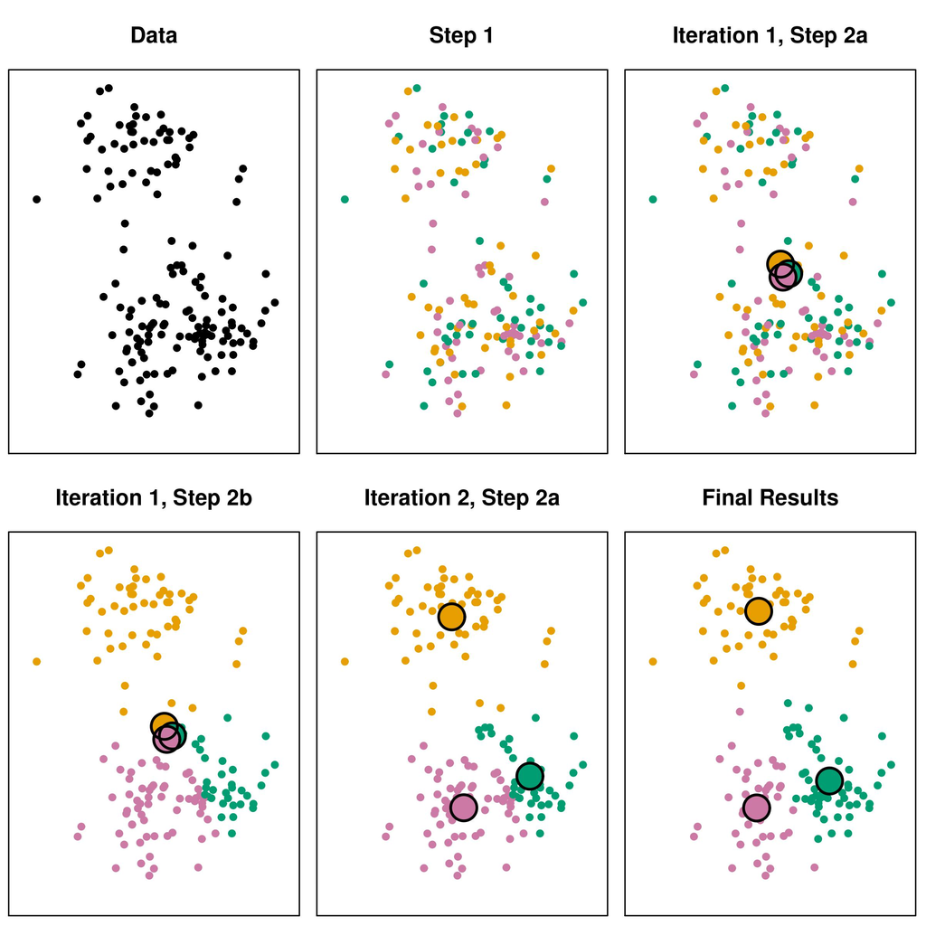

```python
Image("img/k_means_iterations.jpg")
```

Source: StackOverflow

The above illustrates the K-means method.

### Determining $K$

We can construct what is known as **elbow curve** by gradually increasing the numbers of clusters starting from 1 to an abritrary upper limit (e.x. 10). This will give a series of models with different within-cluster distance values, and we can draw a line to connect the distances of the clusters.

This graph will bend like an elbow. Example below.

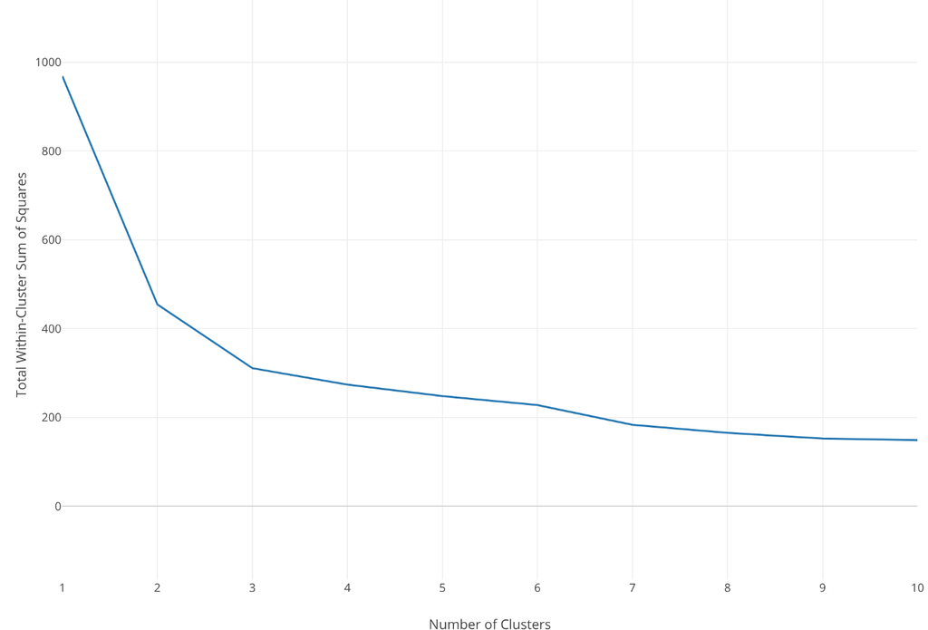

```python
Image("img/elbow_curve.png")
```

Source: blog.exploratory.io

The point where the elbow bends is the optimal $K$. In the above example, the bend occurs at $K=3$ clusters.

## Hierarchical Clustering

### Overview

- Does not require a specified $K$ number of clusters
- Results in a tree-based representation of the observations, called a **dendogram**

It generally works as follows:

- Find closest two items
- Put them together
- Find the next closet item

And requires:

- A defined distance
- A merging approach

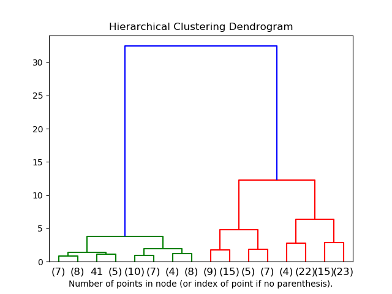

```python
Image("img/dendogram.png")
```

Source: sklearn documentation

How to read the dendogram:

- The leaves at the bottom of each dendogram represent the individual observations
- Any horizontal line that is drawn across this dendogram corresponds to a clustering

### Hierarchical Clustering Algorithm

1. Begin with $n$ observations and a measure (e.x. Euclidean distance) of pairwise **dissimilarities**. At this stage, each observation is its own cluster.
   - These clusters will be combined over time as the dendogram forms
2. For $i = n, n-1, ..., 2$
   1. Identify pairs of clusters that are least dissimilar (aka most simlar) and combine those two clusters.
   2. Compute new pairwise inter-cluster dissimilarites among the $i-1$ remaining clusters

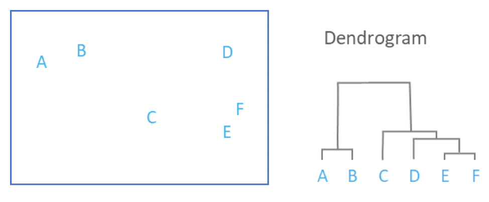

```python
Image('img/dendogram_creation.png')
```

Source: DisplayR

### Types of Dissimilarity

The dissimilarities used in creating dendograms are also known as **linkages**. The four most common types are:

- Complete. Maximum Euclidean distance b/w two clusters
- Average. Average of Euclidean distance b/w two cluster
- Single. Smallest Euclidean distance b/w two clusters
- Centroid. Distance between centroids b/w two clusters

In the above example, we are using a single linkage.

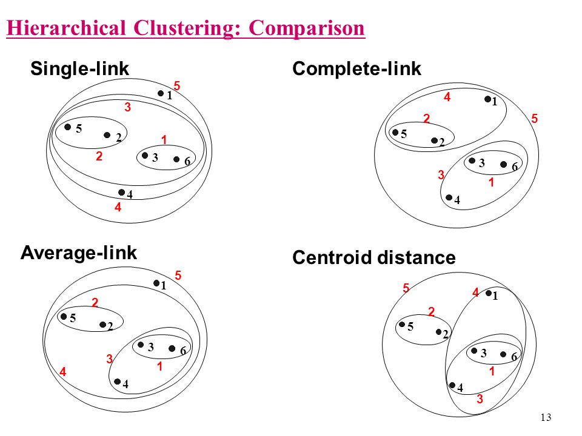

```python
Image("img/linkage_types.jpg")
```

Source: Data Aspirant

## More Resources

[Comprehensive Guide to K-Means Clustering](https://www.analyticsvidhya.com/blog/2019/08/comprehensive-guide-k-means-clustering/)

[Useful Medium Article on Hiearchical Clustering](https://towardsdatascience.com/understanding-the-concept-of-hierarchical-clustering-technique-c6e8243758ec)